# Chapter 5 Homework

D.E. Beaudette

2021-05-07

# Objectives

Using the concepts (and code) from the Numerical Taxonomy and Ordination chapter, compute pair-wise distances between soil series concepts from a suite of 8 phyiscal and climatic variables. These 8 variables (*characteristics*) will be used to develop a climate signature for each soil series (*individual*). Present and interpret the results using both a dendrogram and ordination.

Key steps:

- select your favorite soil series (5-10) and get the data via `fetchOSD`
- develop the **data matrix**
- develop the **distance matrix**, ideally after standardization of characteristics
- develop a dendrogram via hierarchical cluster analysis
- develop an ordination via `sammon` or `metaMDS`
- interpret the results

# Brief Description of the Data Source

## Setup

First, you will need to load some packages. If you have completed the [pre-class assignment](http://ncss-tech.github.io/stats_for_soil_survey/chapters/0_pre-class-assignment/pre-class-assignment.html) then all of these packages should be in place.

```r
library(soilDB)
library(sharpshootR)
library(latticeExtra)
library(reshape2)
library(RColorBrewer)
library(cluster)
library(ape)
library(vegan)
library(MASS)
```

# An Example

The `fetchOSD` function from the `soilDB` package is a simple interface data that have been extracted from the text OSDs and summarized from the current SSURGO snapshot. The `extended=TRUE` argument is used to access the climate data we will be using in this assignment.

```r
soils <- c('Ava', 'Drummer', 'Cisne', 'Pierre', 'Cecil', 'Appling', 'San Joaquin', 'Redding', 'Corning')
s <- fetchOSD(soils, extended = TRUE)
```

Select percentiles are provided for 7 annual climate summaries and elevation. Note that “q50” is the median value and “n” is the number of samples (i.e. number of delineations) used to estimate the percentiles.

| series | climate_var | minimum | q01 | q05 | q25 | q50 | q75 | q95 | q99 | maximum | n |
| --- | --- | --- | --- | --- | --- | --- | --- | --- | --- | --- | --- |
| APPLING | Elevation (m) | 1.00 | 55.00 | 74.00 | 115.00 | 178.00 | 245.00 | 311.00 | 353.00 | 486.00 | 95707 |
| APPLING | Effective Precipitation (mm) | 156.63 | 238.02 | 270.79 | 333.11 | 358.18 | 407.95 | 491.55 | 551.45 | 903.67 | 95707 |
| APPLING | Frost-Free Days | 177.00 | 188.00 | 193.00 | 200.00 | 212.00 | 225.00 | 233.00 | 236.00 | 251.00 | 95707 |
| APPLING | Mean Annual Air Temperature (degrees C) | 11.52 | 12.98 | 13.30 | 13.88 | 15.33 | 16.24 | 16.76 | 17.30 | 18.01 | 95707 |
| APPLING | Mean Annual Precipitation (mm) | 1031.00 | 1068.00 | 1082.00 | 1113.00 | 1146.00 | 1241.00 | 1315.00 | 1347.00 | 1695.00 | 95707 |
| APPLING | Growing Degree Days (degrees C) | 1976.00 | 2290.00 | 2362.00 | 2475.00 | 2723.00 | 2928.00 | 3056.00 | 3176.00 | 3333.00 | 95707 |
| APPLING | Fraction of Annual PPT as Rain | 95.00 | 95.00 | 96.00 | 96.00 | 98.00 | 99.00 | 99.00 | 99.00 | 100.00 | 95707 |
| APPLING | Design Freeze Index (degrees C) | 25.00 | 30.00 | 34.00 | 49.00 | 76.00 | 135.00 | 166.00 | 182.00 | 259.00 | 95707 |

The data look something like this. Your assignment is to compute pair-wise distances between series concepts, using median values (filled circles in the figure) from these data.

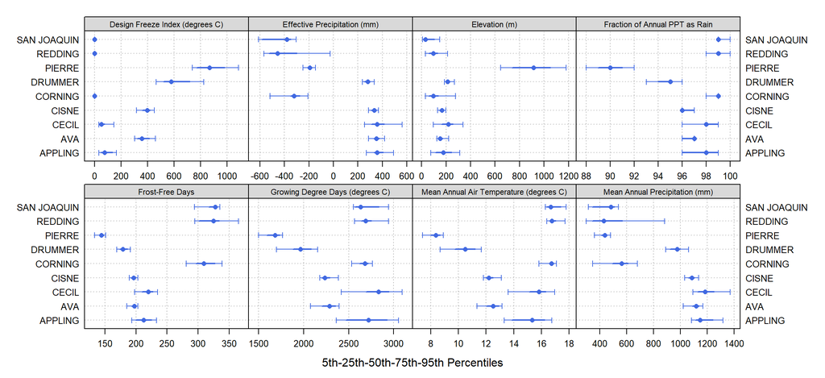

The results might look something like this.

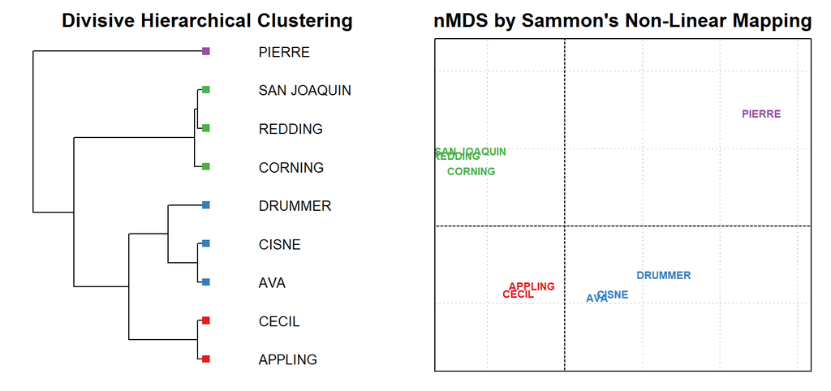

# Your Turn

We will help with the data preparation but it will be up to you to finish the process.

## Get and Prepare Data

Adjust the vector of soil series names assigned to the `soils` character vector below. 5 to 10 should be enough, but feel free to use all [50 state soils](https://raw.githubusercontent.com/ncss-tech/soil-color-book/master/state-soils/state_soils.csv).

```r
# define series names and get data
## you will need to edit this accordingly
soils <- c('your favorite here', 'another favorite', 'maybe the state soil', ...)
s <- fetchOSD(soils, extended = TRUE)

# extract annual climate + elevation data
x <- s$climate.annual

# check structure of the data
str(x)
head(x)
```

Develop the **data matrix**. The data are in “long format” (multiple rows per series, one for each variable) but we need the data in “wide format” (single row per series, columns containing medians).

```r
# re-shape into wide format
x.wide <- dcast(x, series ~ climate_var, value.var = 'q50')
```

Check the structure of `x.wide` one more time: note that the first column contains the soil series name. This is something we want to “keep track of” but not include in the pair-wise distance calculation.

```r
head(x.wide)

# save the series names into row names for later
# remember code examples from chapter 5?
row.names(x.wide) <- x.wide$series


# consider two possible ways of excluding the first column
# [ ] subsetting via negative column index
# this doesn't change x.wide but is handy for an on-the-fly modification
head(x.wide[, -1])
```

## Develop Distance Matrix

Don’t forget to standardize characteristics: `dist()` doesn’t know how to standardize but `daisy()` does. See `?daisy` for clues.

```r
# dist() or daisy()
```

## Hierarchical Clustering

There are several methods and linkage critera. How do you choose?

```r
# hclust(), agnes(), diana()

# possibly convert to ape class for better figures, via hclust class
# as.hclust()
# as.phylo()
```

## Ordination

Note that this is based on the distance matrix. Be sure to inspect the structure of the results with `str()`.

```r
# sammon() or metaMDS()
```

## Visualize Pair-Wise Distances via Dendrogram and Ordination

```r
# most hierarchical clustering objects have a plot() method
```

## Interpret

- Do these figures tell you anything that you didn’t already know?
  - Does the hierarchy suggested by the dendrogram mean anything?
  - Does cutting the dendrogram into *n* clusters result in groups that follow intuition?
  - Which representation (dendrogram vs. ordination) is more useful?
  - Do the axes of the 2D representation (e.g. ordination) of the original 8D data space map to meaningful climatic gradients?
  - How might we use the pair-wise distances computed from select characteristics of all soil series concepts?